# ggplot2_training

Install tidyverse and ggthemes packages first if needed, then load the libraries

## Introduction

- ggplot is the data visualization package
- based on *grammar of graphics*
- data via geom -> coordinate system -> plot…

```r
mpg
```

```
## # A tibble: 234 x 11
##    manufacturer model    displ  year   cyl trans   drv     cty   hwy fl
##    <chr>        <chr>    <dbl> <int> <int> <chr>   <chr> <int> <int> <chr>
##  1 audi         a4        1.80  1999     4 auto(l… f        18    29 p
##  2 audi         a4        1.80  1999     4 manual… f        21    29 p
##  3 audi         a4        2.00  2008     4 manual… f        20    31 p
##  4 audi         a4        2.00  2008     4 auto(a… f        21    30 p
##  5 audi         a4        2.80  1999     6 auto(l… f        16    26 p
##  6 audi         a4        2.80  1999     6 manual… f        18    26 p
##  7 audi         a4        3.10  2008     6 auto(a… f        18    27 p
##  8 audi         a4 quat…  1.80  1999     4 manual… 4        18    26 p
##  9 audi         a4 quat…  1.80  1999     4 auto(l… 4        16    25 p
## 10 audi         a4 quat…  2.00  2008     4 manual… 4        20    28 p
## # ... with 224 more rows, and 1 more variable: class <chr>
```

Shortcut for inserting code chunk in Rmd: alt-command-I Can learn more about datasets in R by typing “?datasetname”

Arguements for ggplot: data, aesthetics (what to plot on axes); need to use a geom_ to tell ggplot *how* to plot

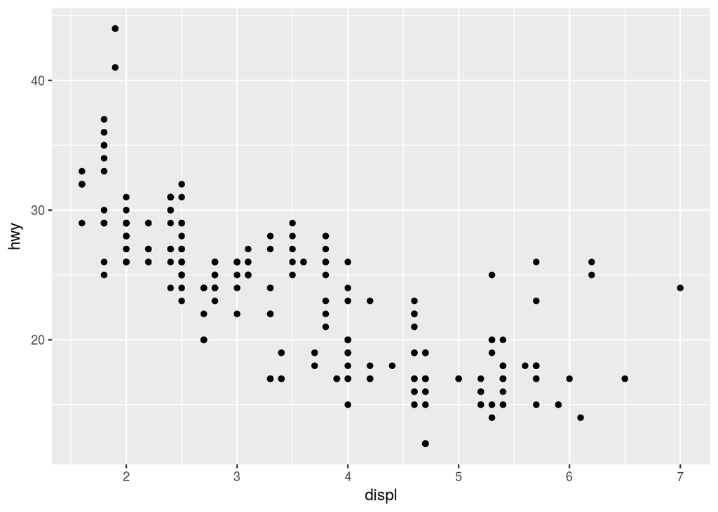

```r
ggplot(data = mpg, aes(x = displ, y = hwy)) + geom_point()
```

```r
#assign this plot to a variable

car_plot <- ggplot(data = mpg, aes(displ, hwy))
```

Can use this approach to use same set up to do multiple plots

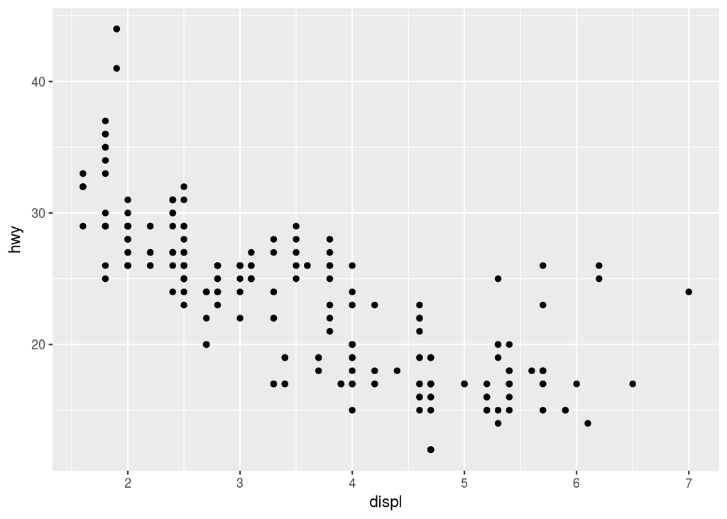

```r
car_plot + geom_point()
```

Remember, the “+” sign must be at the end of the line, cannot be at beginning of new indented line

## Different Formatting

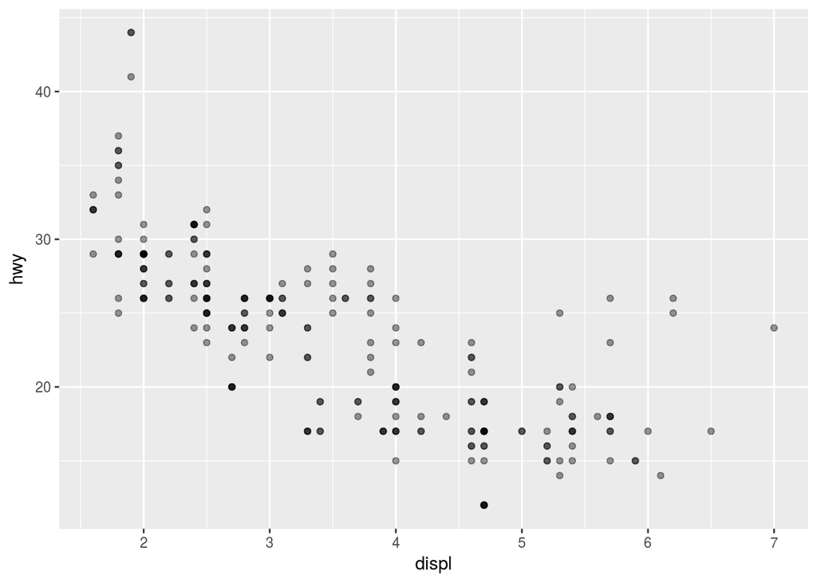

```r
ggplot(data = mpg, aes(x = displ, y = hwy)) +
  geom_point(alpha = 0.4)
```

Alpha adds transparency to the plotted data; this allows us to see that there are actually points stacked on top of each other here!

Another thing you can do is add color:

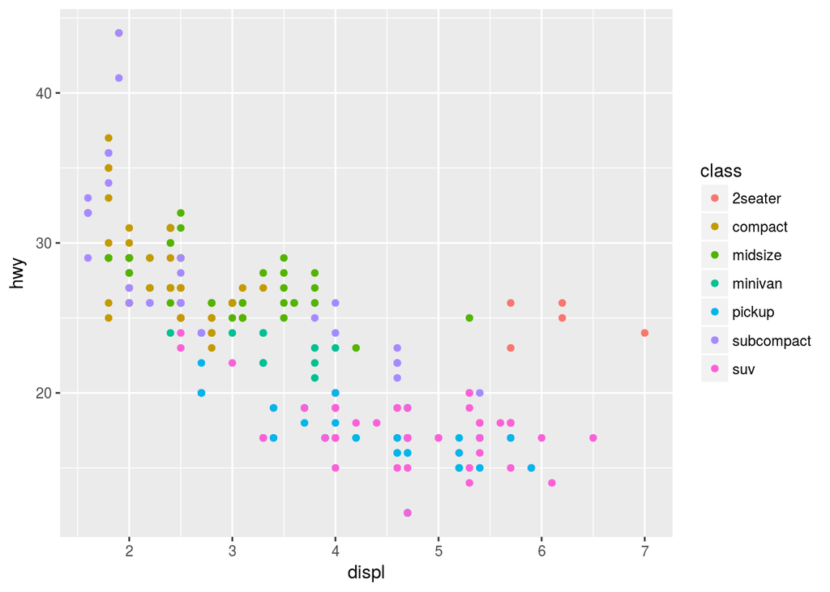

```r
ggplot(data = mpg, aes(x = displ, y = hwy)) +
  geom_point(aes(color = class))
```

The “aes(color = class)” tells ggplot we want the points colored by the “class” of car

ggplot has a limited number of default shapes

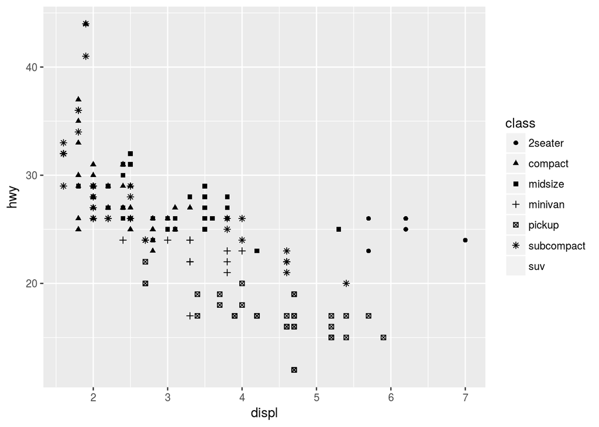

```r
ggplot(data = mpg) +
  geom_point(aes(x = displ, y = hwy, shape = class))
```

Specifying x and y in aesthetics in the ggplot() portion essentially names them as global aesthetics, and unless specify x and y in geom_ aes() arguements, will use those global specifications

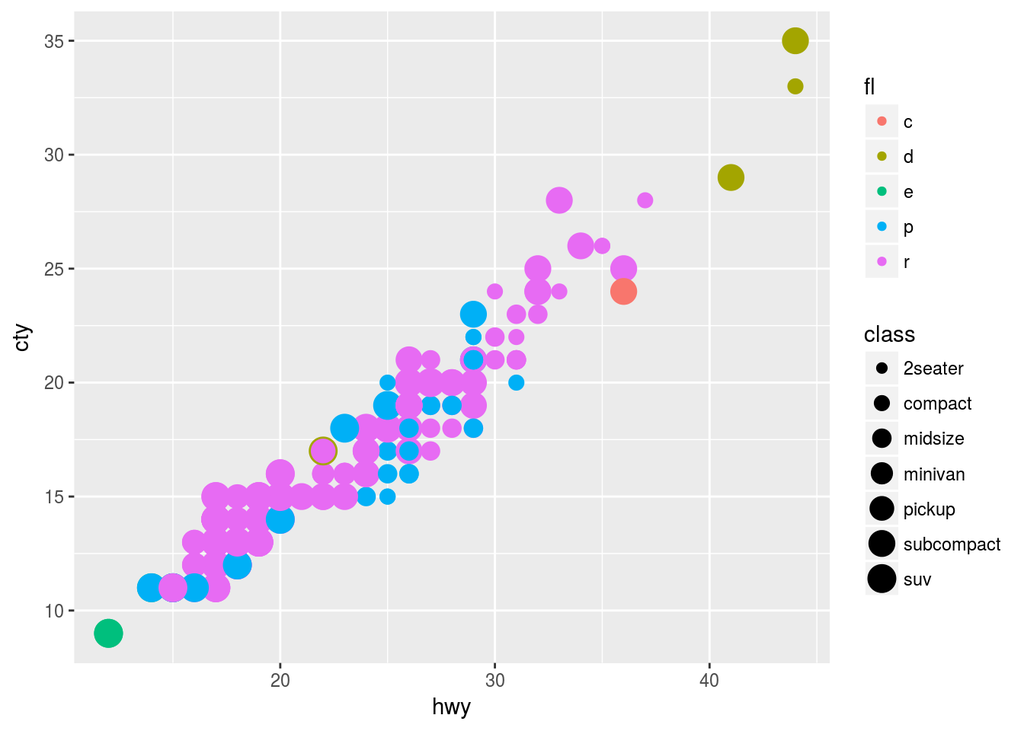

```r
ggplot(data = mpg, aes(x = hwy, y = cty)) +
  geom_point(aes(size = class, color = fl))
```

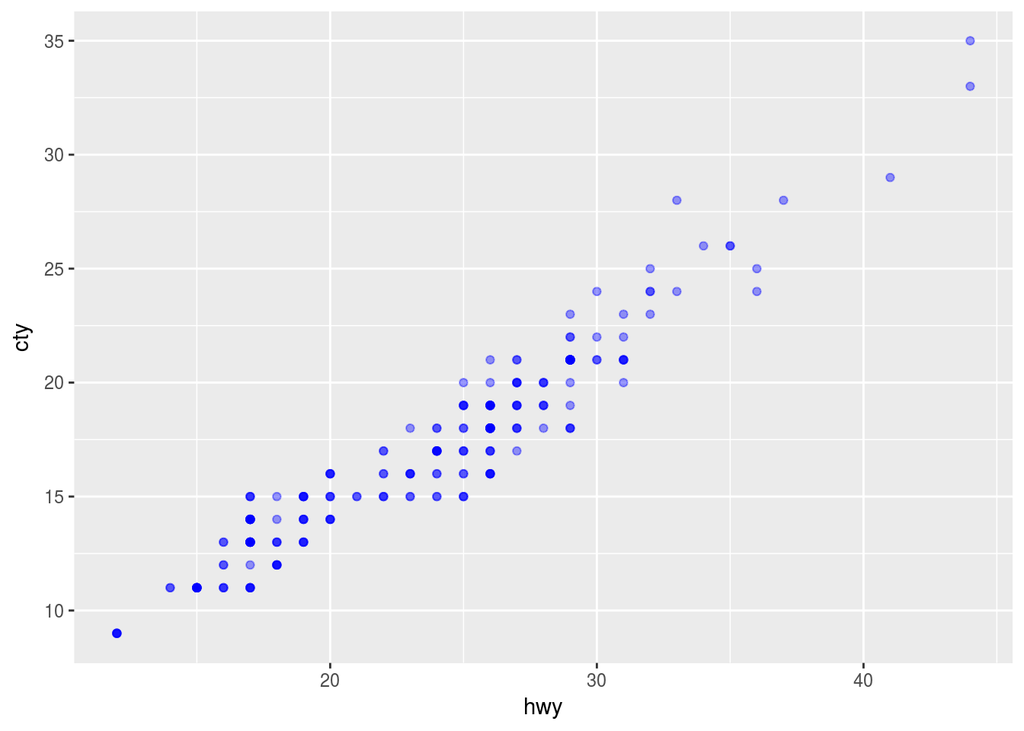

```r
ggplot(data = mpg) +
  geom_point(aes(x = hwy, y = cty), color = "blue", alpha = 0.4)
```

If inside the aes(), saying to look at something within the data; patterns. Outside the aes() is just generally plot style formatting

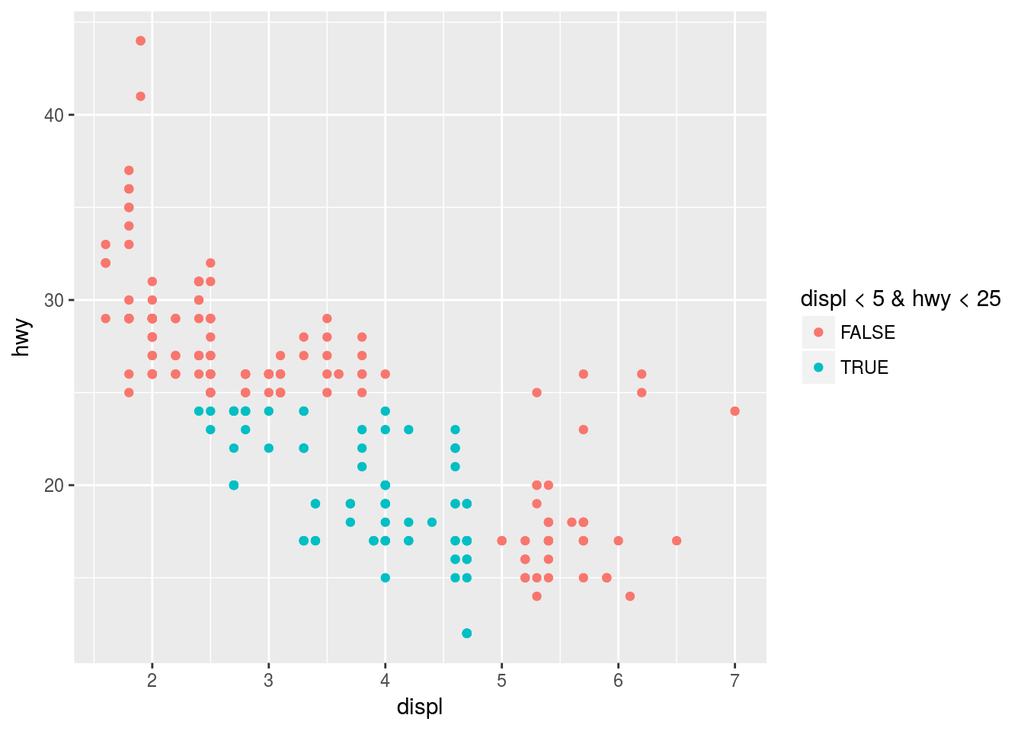

```r
ggplot(data = mpg) + geom_point(aes(x = displ, y = hwy, color = displ < 5 & hwy <25 ))
```

Can map aesthetics to something other than a variable name; can map to a condition on variable

## Faceting

Faceting allows to split dataset based on characteristics of the dataset

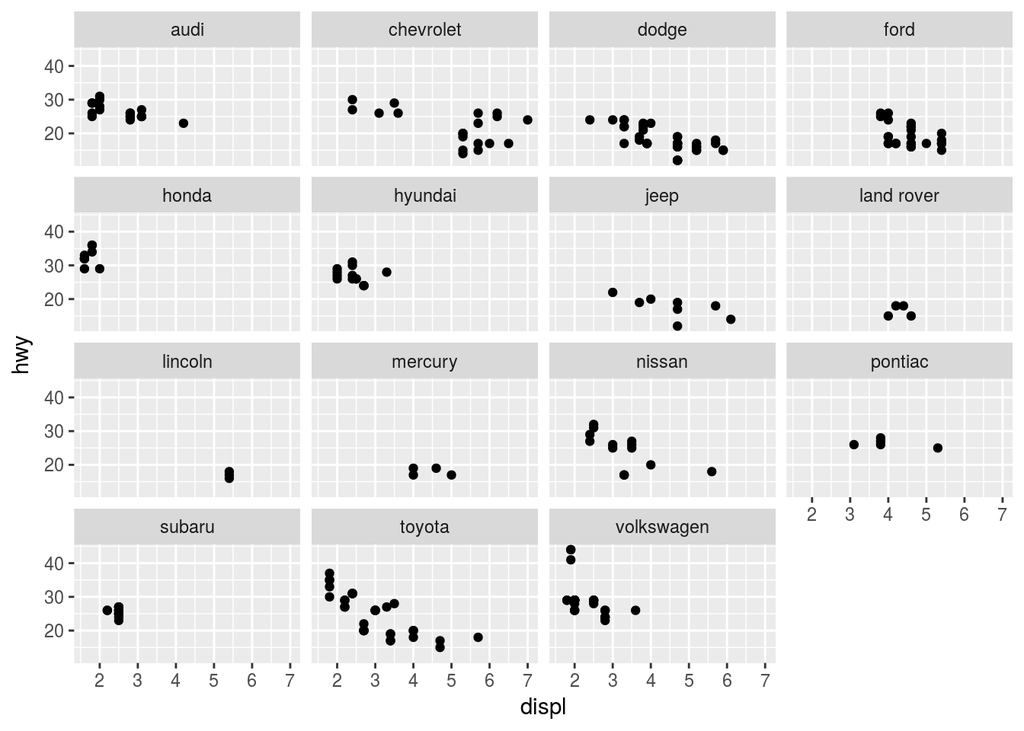

```r
ggplot(data = mpg) +
  geom_point(aes(x = displ, y = hwy)) +
  facet_wrap(~ manufacturer)
```

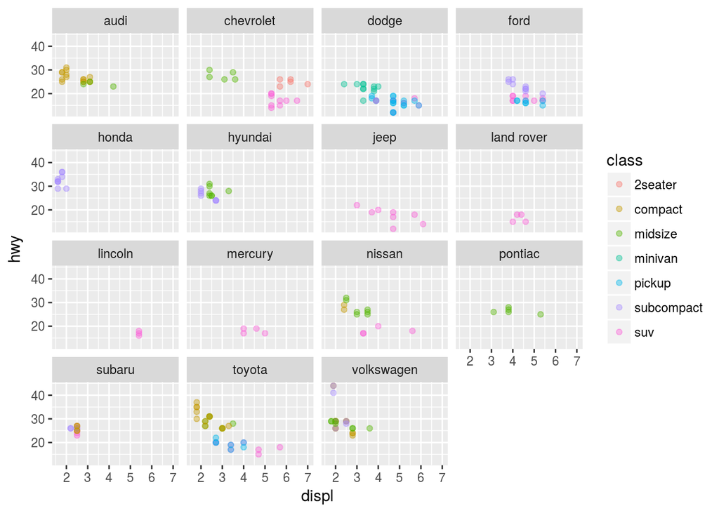

```r
ggplot(data = mpg) +
  geom_point(aes(x = displ, y = hwy, color = class), alpha = 0.4) +
  facet_wrap(~ manufacturer)
```

Same graph as above but without grey background, by adding a “theme”:

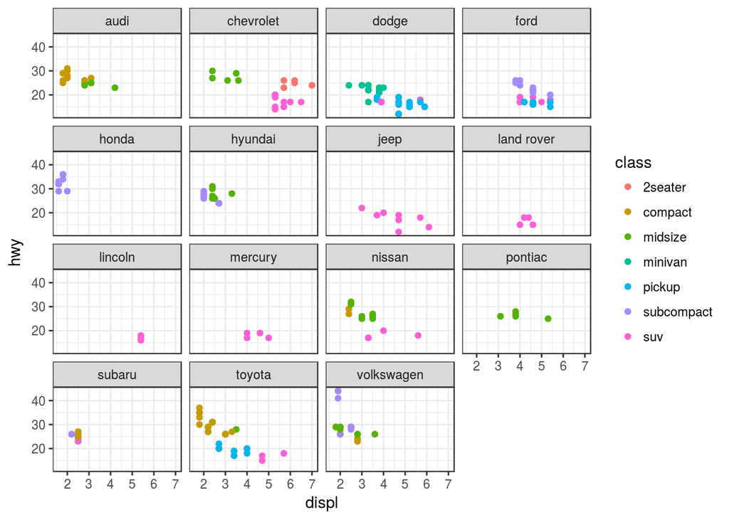

```r
ggplot(data = mpg) +
  geom_point(aes(x = displ, y = hwy, color = class)) +
  facet_wrap(~ manufacturer) +
  theme_bw()
```

[Introduction to ggthemes] [https://cran.r-project.org/web/packages/ggthemes/vignettes/ggthemes.html]

```r
library(ggthemes)
```

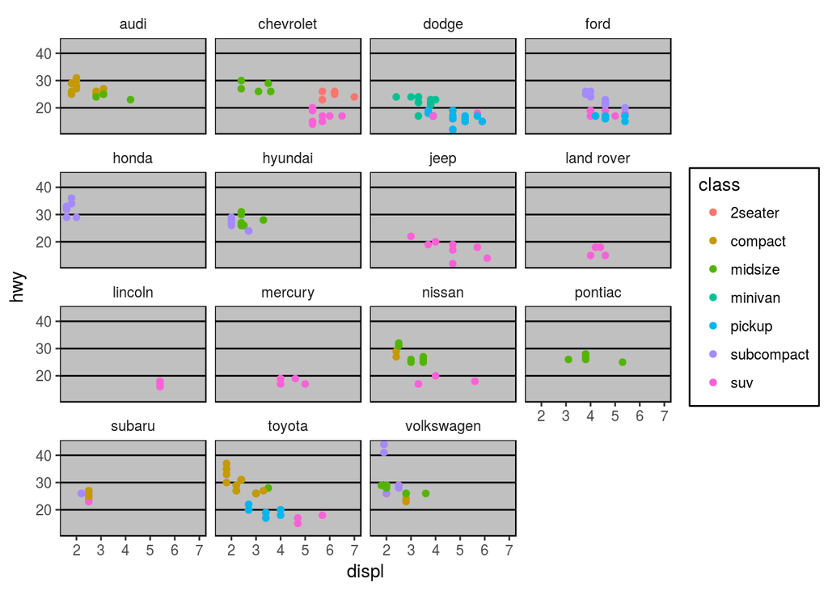

```r
ggplot(data = mpg) +
  geom_point(aes(x = displ, y = hwy, color = class)) +
  facet_wrap(~ manufacturer) +
  theme_excel()
```

## Playing with Geoms_

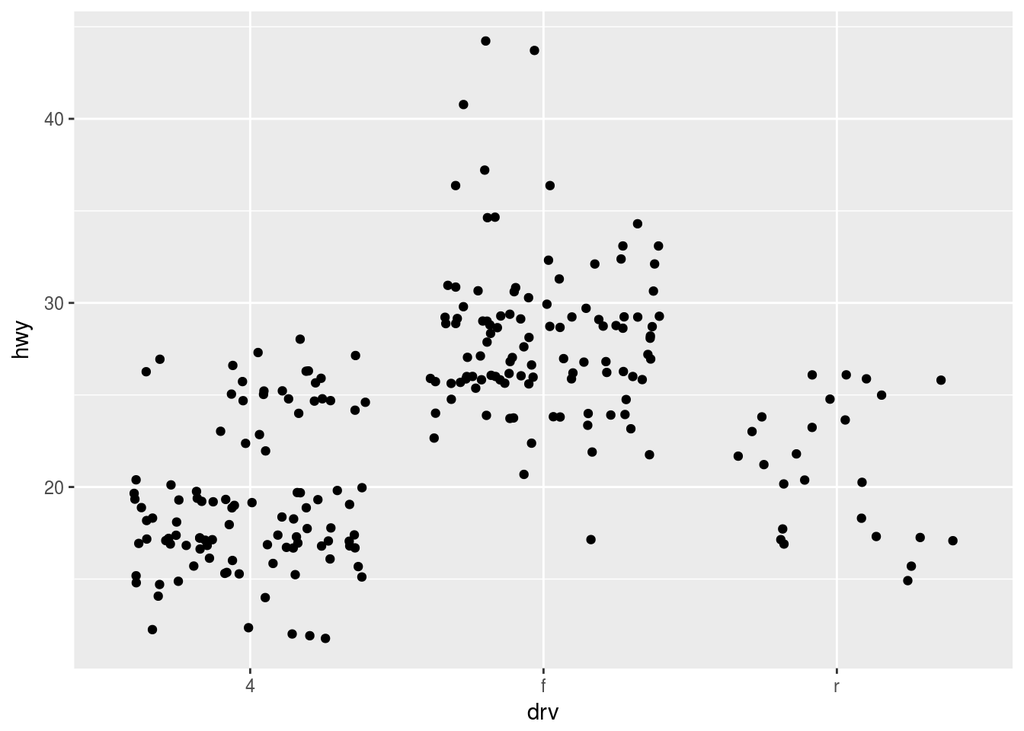

```r
ggplot(data = mpg, aes(x = drv, y = hwy)) +
  geom_jitter()
```

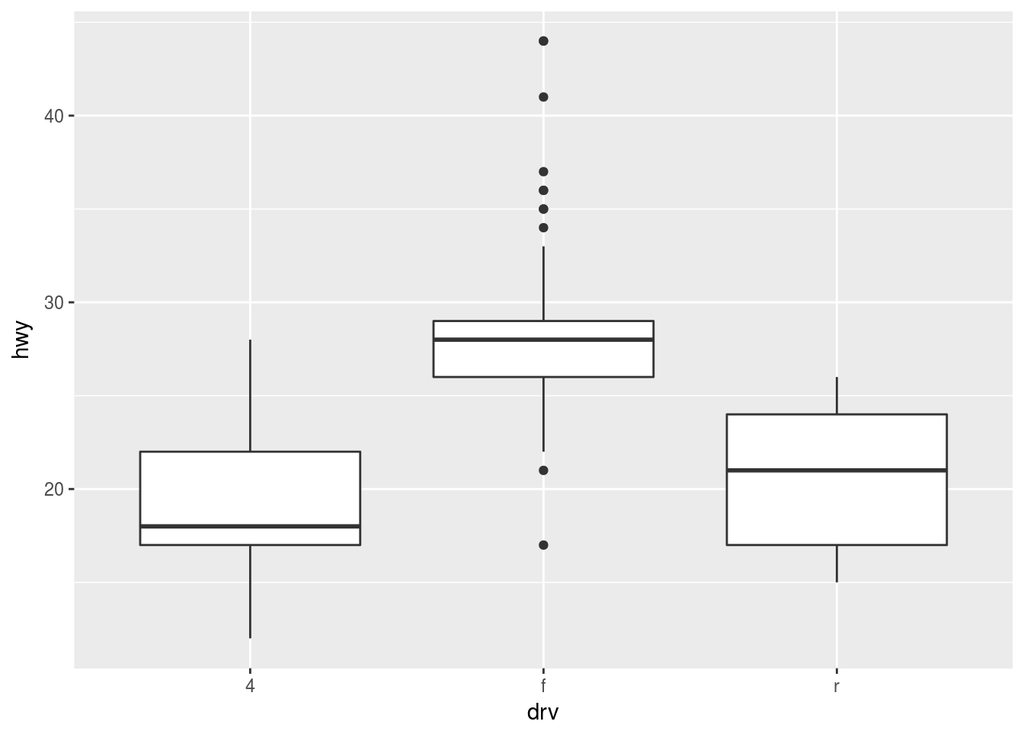

```r
ggplot(data = mpg, aes(x = drv, y = hwy)) +
  geom_boxplot()
```

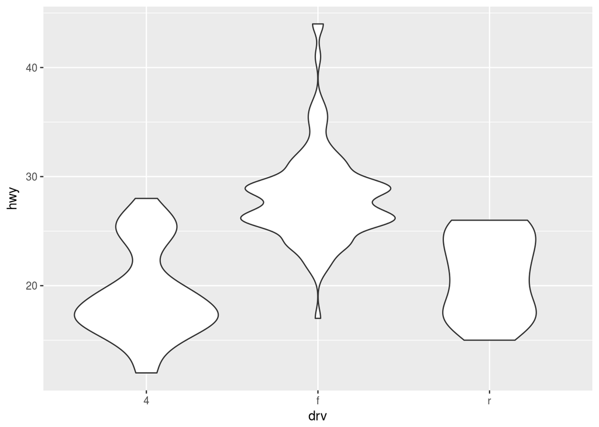

```r
ggplot(data = mpg, aes(x = drv, y = hwy)) +
  geom_violin()
```

Using multiple kinds of geoms on one plot

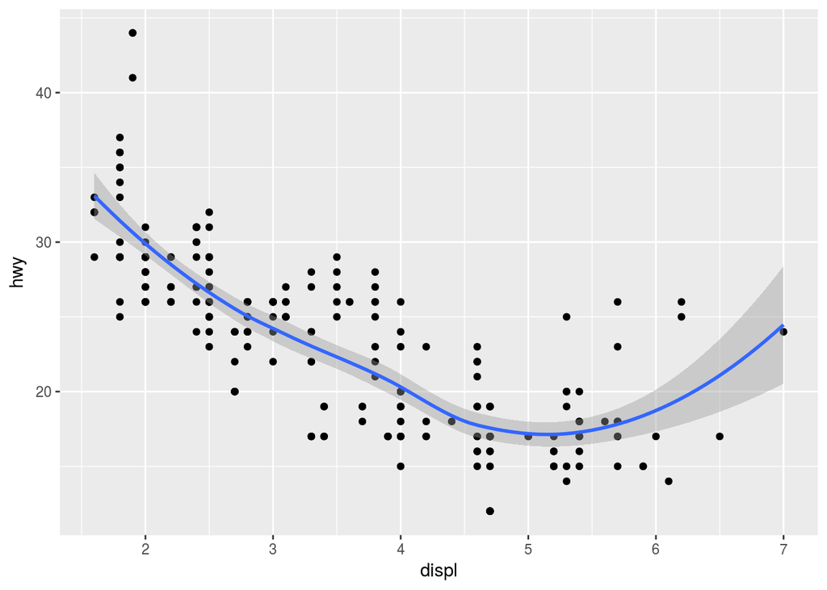

```r
ggplot(data = mpg, aes(x = displ, y = hwy)) +
  geom_point() +
  geom_smooth()
```

Editing formatting/style of plots by geom_

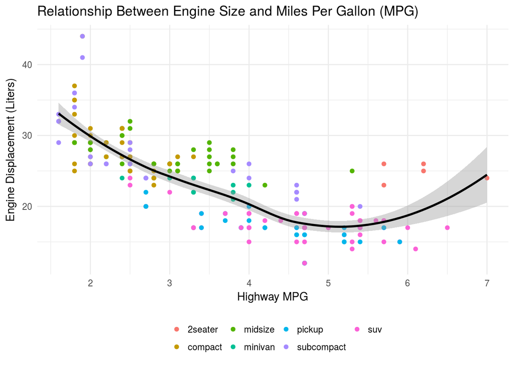

```r
ggplot(data = mpg, aes(x = displ, y = hwy)) +
  geom_point(aes(color = class)) +
  geom_smooth(color = "black") +
  theme_minimal() +
  theme(legend.title=element_blank(), legend.position = "bottom") +
  ggtitle("Relationship Between Engine Size and Miles Per Gallon (MPG)") +
  xlab("Highway MPG") + ylab("Engine Displacement (Liters)")
```

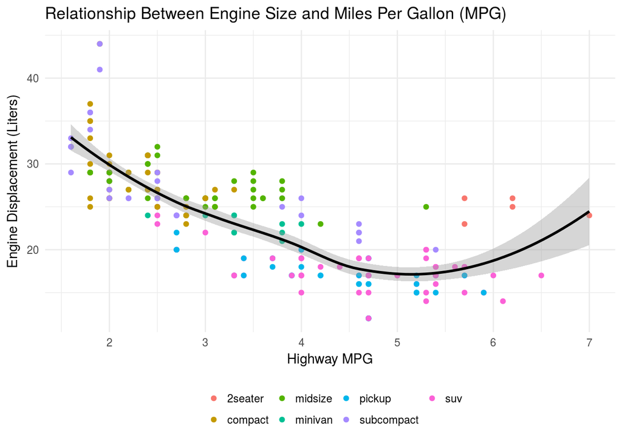

```r
ggplot(data = mpg, aes(x = displ, y = hwy)) +
  geom_point(aes(color = class)) +
  geom_smooth(color = "black") +
  theme_minimal() +
  theme(legend.title=element_blank(), legend.position = "bottom") +
  labs(title = "Relationship Between Engine Size and Miles Per Gallon (MPG)", x = "Highway MPG", y = "Engine Displacement (Liters)")
```

## Bar Charts

Default of bar charts is “count” type; histograms etc bin data how you tell it to and then count within the bins

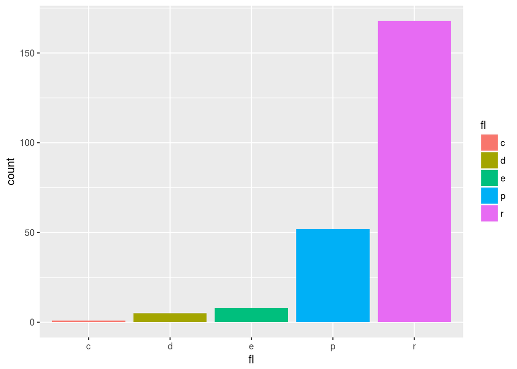

```r
ggplot(data = mpg) +
  geom_bar(aes(x = fl, fill = fl))
```

Color aesthetic acts on the line, while fill acts on the full bar

Color and x-axes categories are redundant in graph above; visualizing fuel type by class is more interesting - automatically creates a stacked bar chart

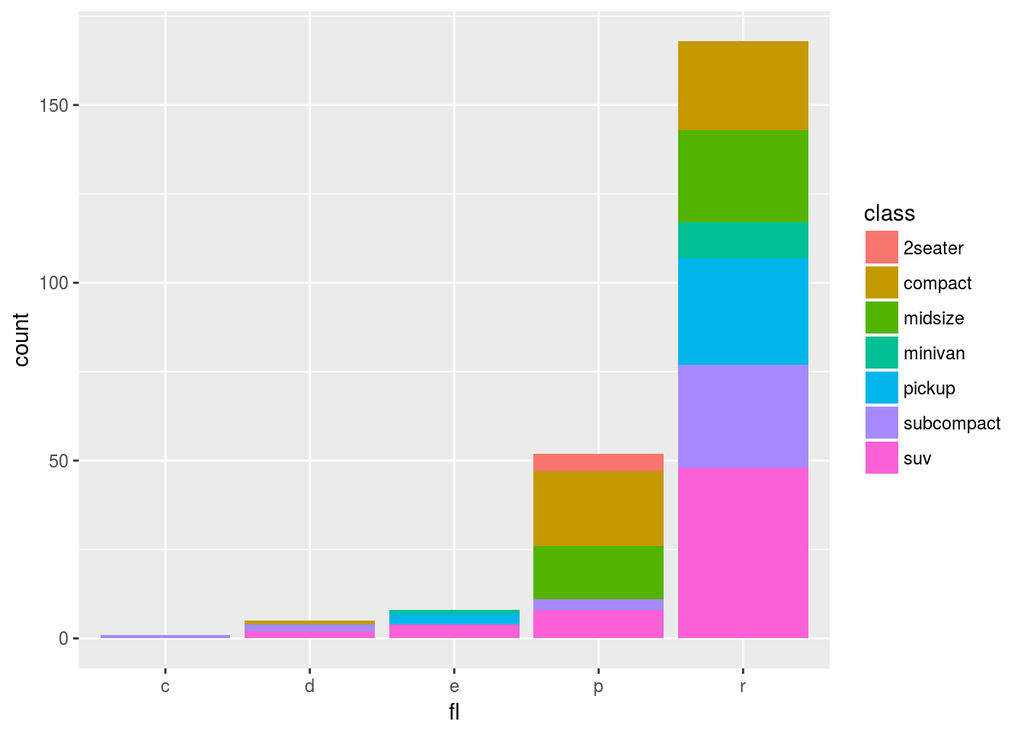

```r
ggplot(data = mpg) +
  geom_bar(aes(x = fl, fill = class))
```

To look at proportion rather than count, can use the position = “fill”

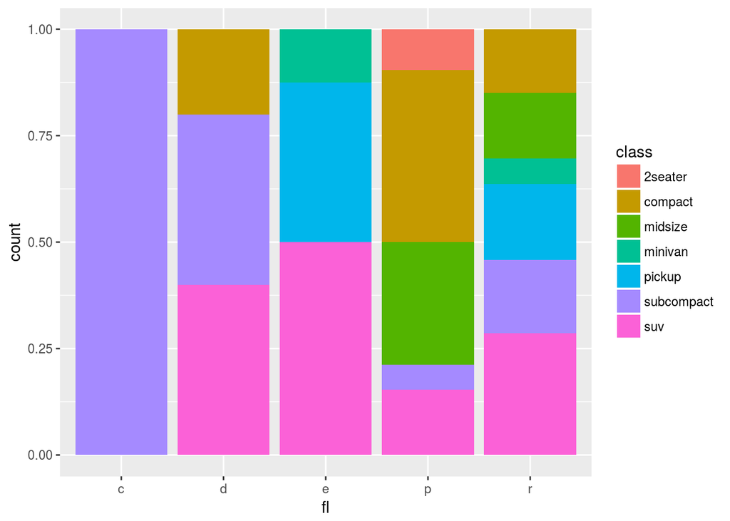

```r
ggplot(data = mpg) +
  geom_bar(aes(x = fl, fill = class), position = "fill")
```

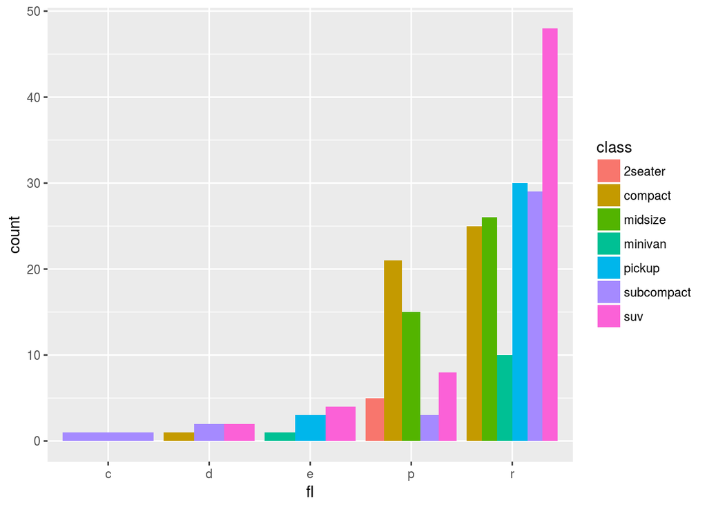

```r
ggplot(data = mpg) +
  geom_bar(aes(x = fl, fill = class), position = "dodge")
```

To add meaningful labels…

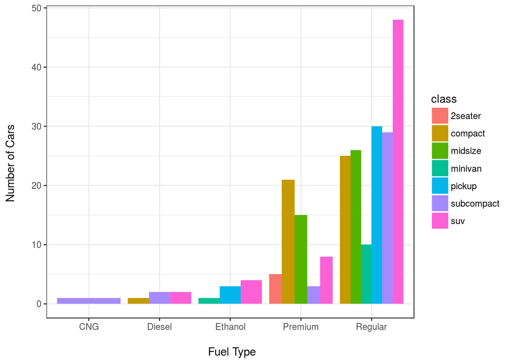

```r
ggplot(data = mpg) +
  geom_bar(aes(x = fl, fill = class), position = "dodge") +
  theme_bw() +
  scale_x_discrete(labels = c("CNG", "Diesel", "Ethanol", "Premium", "Regular")) +
  labs(x = "\n Fuel Type", y = "Number of Cars \n")
```

**Picking a Color Palette!**

scale_fill_brewer:

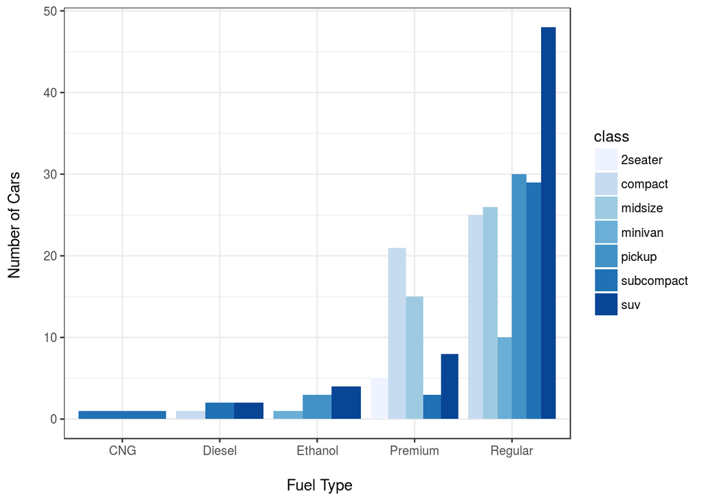

```r
ggplot(data = mpg) +
  geom_bar(aes(x = fl, fill = class), position = "dodge") +
  theme_bw() +
  scale_x_discrete(labels = c("CNG", "Diesel", "Ethanol", "Premium", "Regular")) +
  labs(x = "\n Fuel Type", y = "Number of Cars \n") +
  scale_fill_brewer(palette = "Blues")
```

To view palettes from RColorBrewer:

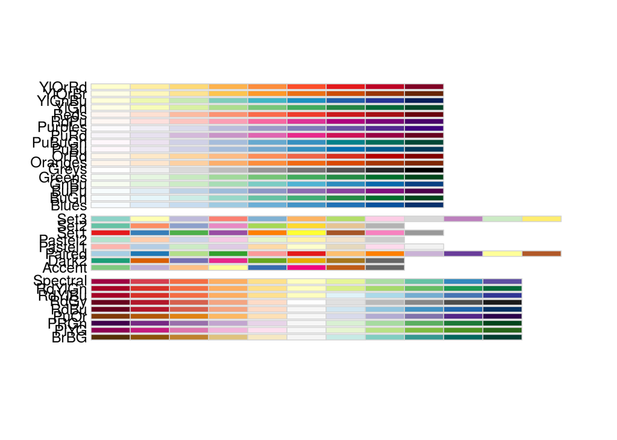

```r
RColorBrewer::display.brewer.all()
```

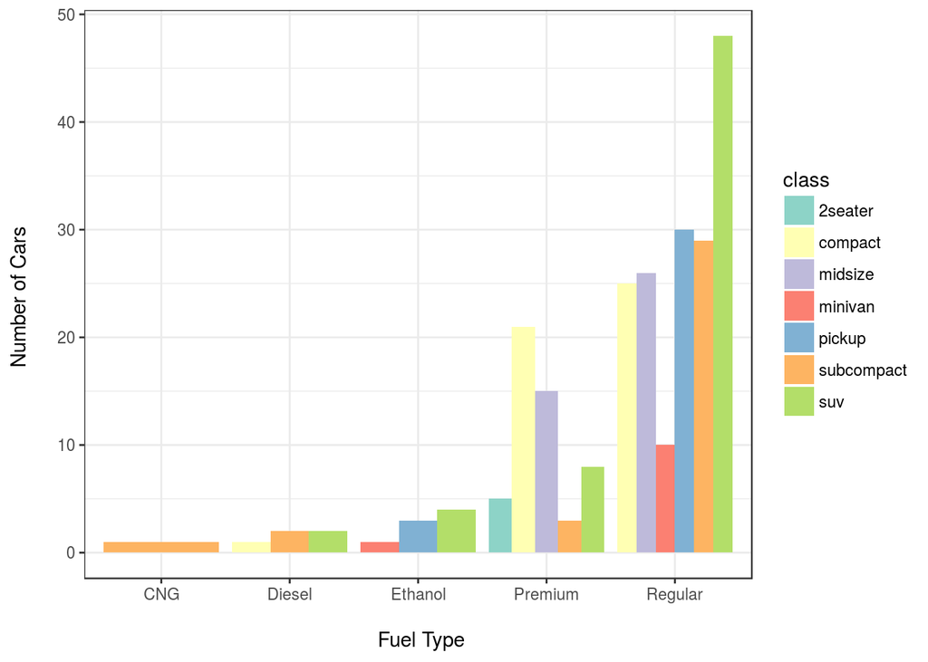

```r
ggplot(data = mpg) +
  geom_bar(aes(x = fl, fill = class), position = "dodge") +
  theme_bw() +
  scale_x_discrete(labels = c("CNG", "Diesel", "Ethanol", "Premium", "Regular")) +
  labs(x = "\n Fuel Type", y = "Number of Cars \n") +
  scale_fill_brewer(palette = "Set3")
```

## Saving GGPlots as Images

Using ggsave()

1. name your plot
2. use ggsave(what to save as filename, name of thing to save, width = number, length = number)

```r
myplot <- ggplot(data = mpg) +
  geom_bar(aes(x = fl, fill = class), position = "dodge") +
  theme_bw() +
  scale_x_discrete(labels = c("CNG", "Diesel", "Ethanol", "Premium", "Regular")) +
  labs(x = "\n Fuel Type", y = "Number of Cars \n") +
  scale_fill_brewer(palette = "Set3")

ggsave("my_ggplot.pdf", myplot, width = 5, height = 6)
```

PDFs are much smaller files, and often easier to work with than PNGs. Can define the resolution (dpi) with ggsave as well.